# Introduction to bayesplot (mcmc_ series)

```r
mcmc_areas_ridges_data(samples, regex_pars = "^eta\\[", prob = 0.95, prob_outer = 1)
```

```
# A tibble: 16,384 x 5
   parameter interval interval_width     x density
   <fct>     <chr>             <dbl> <dbl>   <dbl>
 1 eta[1]    inner              0.95 -1.54  0.0575
 2 eta[1]    inner              0.95 -1.53  0.0578
 3 eta[1]    inner              0.95 -1.53  0.0581
 4 eta[1]    inner              0.95 -1.53  0.0584
 5 eta[1]    inner              0.95 -1.52  0.0588
 6 eta[1]    inner              0.95 -1.52  0.0591
 7 eta[1]    inner              0.95 -1.52  0.0594
 8 eta[1]    inner              0.95 -1.51  0.0598
 9 eta[1]    inner              0.95 -1.51  0.0601
10 eta[1]    inner              0.95 -1.51  0.0604
# ... with 16,374 more rows
```

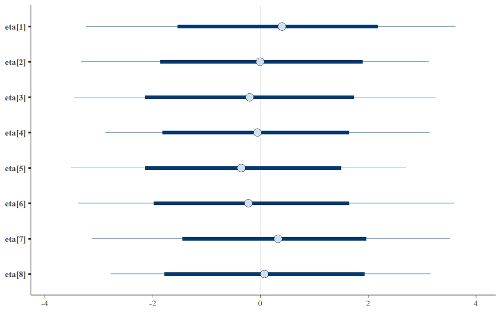

```r
## 区間だけ図示したい
mcmc_intervals(samples, regex_pars = "^eta\\[", prob = 0.95, prob_outer = 1,
    point_est = "mean")
```

```r
mcmc_intervals_data(samples, regex_pars = "^eta\\[", prob = 0.95, prob_outer = 1,
    point_est = "mean")
```

```
# A tibble: 8 x 9
  parameter outer_width inner_width point_est    ll     l        m     h
  <fct>           <dbl>       <dbl> <chr>     <dbl> <dbl>    <dbl> <dbl>
1 eta[1]              1        0.95 mean      -3.23 -1.54  0.399    2.18
2 eta[2]              1        0.95 mean      -3.32 -1.86 -0.00396  1.90
3 eta[3]              1        0.95 mean      -3.46 -2.14 -0.200    1.74
4 eta[4]              1        0.95 mean      -2.88 -1.82 -0.0575   1.65
5 eta[5]              1        0.95 mean      -3.51 -2.14 -0.361    1.50
6 eta[6]              1        0.95 mean      -3.38 -1.98 -0.227    1.65
7 eta[7]              1        0.95 mean      -3.13 -1.45  0.325    1.97
8 eta[8]              1        0.95 mean      -2.78 -1.78  0.0743   1.94
# ... with 1 more variable: hh <dbl>
```

ポイントは、regax_parsで正規表現が指定できるようになります。  
今回のように“eta”だけ指定したい場合、“theta”もとってきてしまうので、“eta[”と指定して“eta”のみ抽出できるようにしているのが“^eta\[”です。

これに関しては、正規表現も簡単に使えるのが結構便利かも。

そして、最後は、事後分布(事後乱数)をヒストグラムやバイオリンプロット、散布図で書く場合

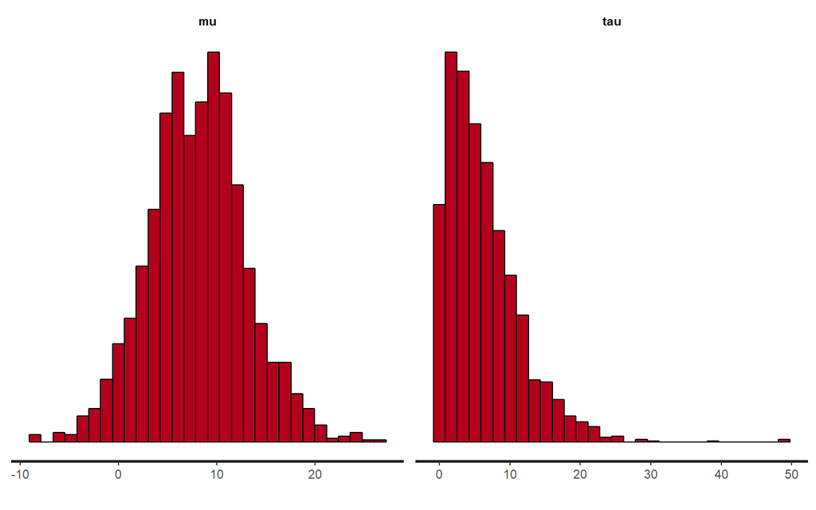

```r
## デフォルト
stan_hist(fit, pars = c("mu", "tau"))
```

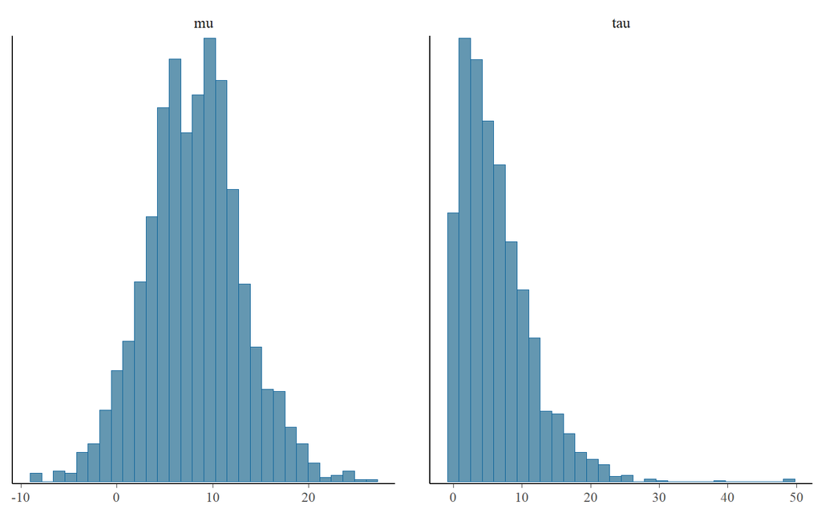

```r
## beyasplot
mcmc_hist(samples, pars = c("mu", "tau"))
```

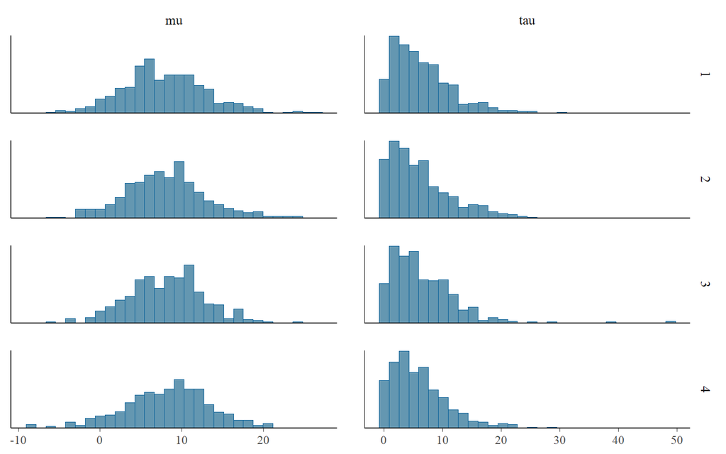

```r
mcmc_hist_by_chain(samples, pars = c("mu", "tau"))  ## chain毎
```

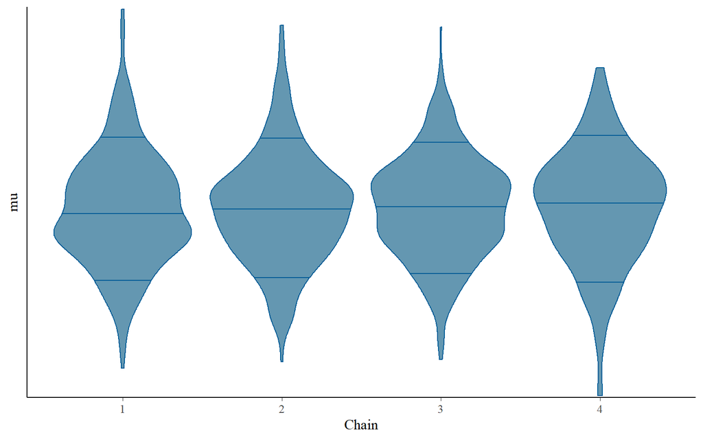

```r
## violin plot
mcmc_violin(samples, pars = "mu")
```

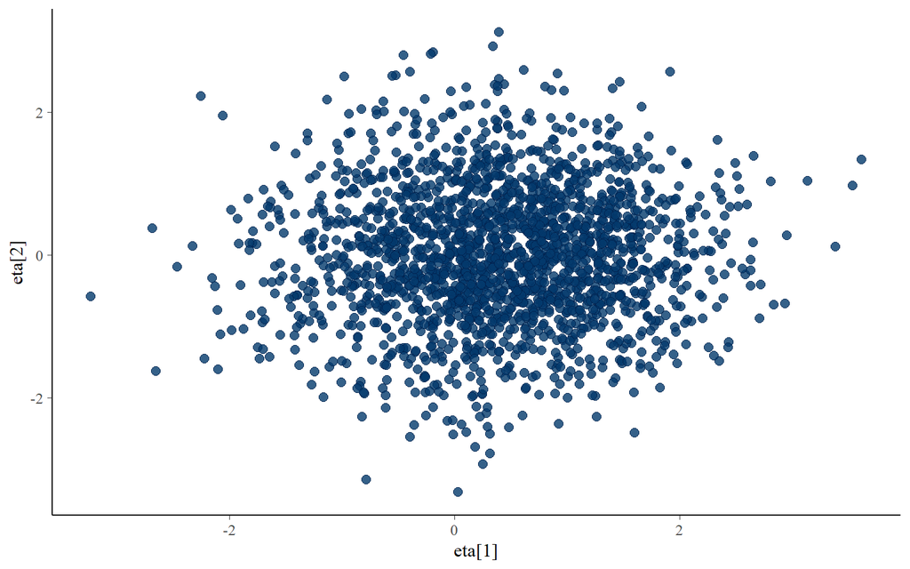

```r
## 散布図
mcmc_scatter(samples, pars = c("eta[1]", "eta[2]"))
```

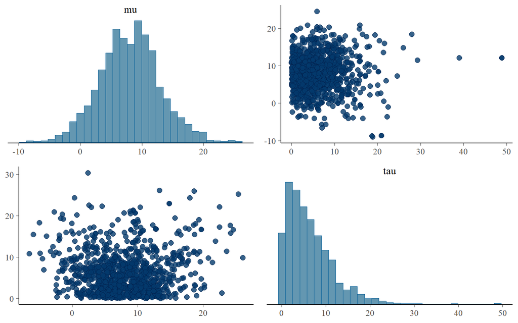

```r
## ヒストグラム(density)と散布図同時に
mcmc_pairs(samples, pars = c("mu", "tau"), diag_fun = c("hist"))  ## 'hist' → 'dens'で変更可能
```

これは割とそのままですね～  
mcmc_pairsは3変数以上でも出せますが、重くなるので注意が必要です。